# Demos of SIR model

2020/03/14

## Classical SIR model

The SIR model is a classical infectious disease model. It can show the process from the onset to the end of an infectious disease.There are three important variables:

1. S(t)—- Susceptible population
2. I(t)—- Infected population
3. R(t)—- recovered population

And there is an ideal condition: the total population of a city stays the same

$$S(t)+I(t)+R(t)=P$$
$P$ is a definite value

The concrete form of the model:
$$\begin{cases}
\frac{dS(t)}{d(t)}=-\beta S(t)I(t)\\
\frac{dI(t)}{d(t)}=\beta S(t)I(t)-\gamma I(t)\\
\frac{dR(t)}{d(t)}=\gamma I(t)\\
\end{cases}$$

Assuming that the number of susceptible persons that can be infected by a patient per unit time at time $t$ is proportional to the total number of susceptible persons $S(t)$ in this environment, the proportionality coefficient is set to be $\beta$, so that the number of patients infected per unit time at time $t$ is equal to $\beta S(t)I(t)$.At time $t$, the number of patients removed per unit time is proportional to the number of patients, the proportionality coefficient is $\gamma$, and the number of patients removed per unit time is $\gamma I(t)$.

## SIR model in R—-Simulate the outbreak of COVID-19 in wuhan

```r
library(deSolve)
```

Bulid the SIR model

```r
sir <- function(time, state, pars) {
  with(as.list(c(state, pars)), {
    dS <- -beta * S * I/N
    dI <- beta * S * I/N - gamma * I
    dR <- gamma * I
    return(list(c(dS, dI, dR)))
  })
}
```

Set each parameter for the SIR model

```r
N <- 1.5e8 # Total population
I0 <- 1 # Initial number of infections
RM0 <- 0 # Initial number of people removed
S0 <- N - I0 - RM0 # Initial number of susceptible populations
init <- c(S = S0, I = I0, R = RM0) # The initial value
# The following parameters are assumed to be constant under the model
pars <- c(
  beta = 0.65, # Effective contact rate
  gamma = 0.25, # Removal rate
  N = N # population
  )
times <- seq(0, 150, by = 1)
res <- as.data.frame(ode(y = init, times = times, func = sir, parms = pars))
```

Result visualization

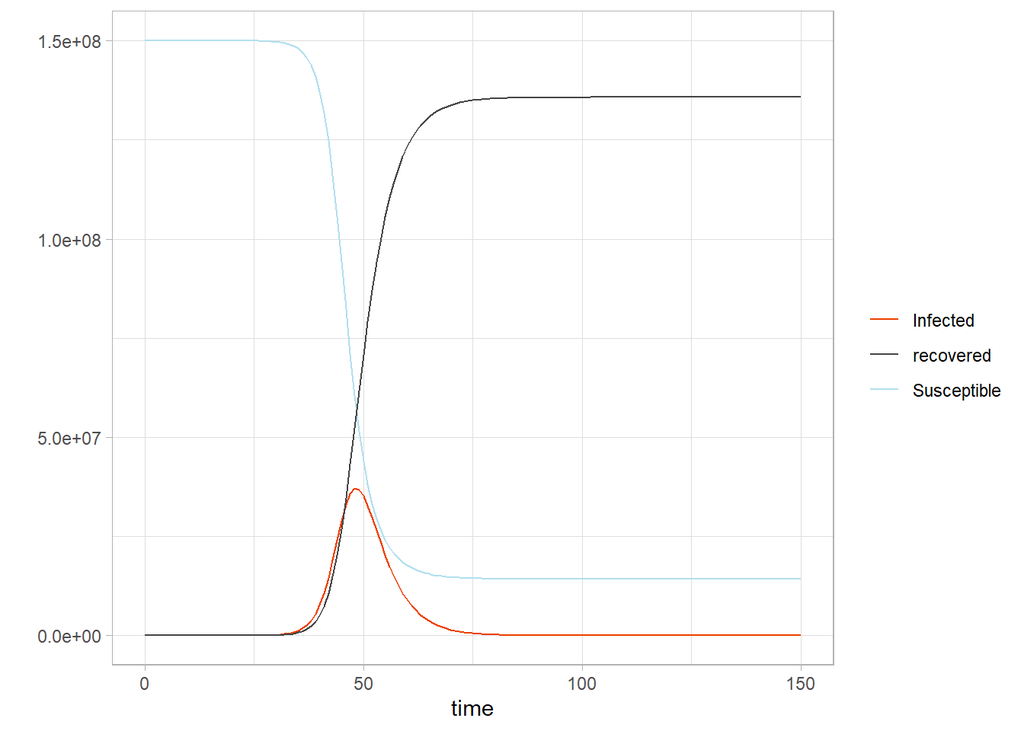

```r
library(ggplot2)
ggplot(res) +
  geom_line(aes(x = time, y = S, col = 'Susceptible'))+
  geom_line(aes(x = time, y = I, col = 'Infected'))+
  geom_line(aes(x = time, y = R, col = 'recovered'))+
  theme_light(base_family = 'Kai') +
  scale_colour_manual("",
  values=c("Susceptible" = "lightblue2", "Infected" = "orangered2", "recovered" = "gray27")
  ) +
  scale_y_continuous('')
```